# **QTM350 - Final Project**

Team: Ron Huang, Rita Miao, Amy Kim, Alexandra Iotzova

# **Introduction: Our story & Amazon ML service of choise**

## As students interested in the intersection of the financial markets and the data science world, we are eager to apply analytical and scholarly approaches to finance.

### As a group:

we are particularly fascinated by the financial markets in the last century and want to explore topics such as the historical returns of stock and bond markets during the recession days of 1930s (many researchers omit data from the Great Depression and the second world war to start the analysis in the 1950s). As the global financial market of today undergoes many unprecedented challenges, we want to go back to history and see if any lessons can be discovered.

However, many reports and research back then are not digitized but only available in hard copies of books, newspapers, and other printouts, and it is a demanding process to manually input all the data to digital data frames that computers today can understand.

### Personal experience and applications:

Amy - From working as a Treasury intern at Inspire Brands, I realized that many businesses are working to move their current databases to an online, automated platform rather than manual inputting of data from files. This past summer, I experimented with extracting data from digital files and automatically inputting them into an xlsx. formatted file through Power Query in Excel, as well as Python. However, after further research, I learned that the AWS Textract program may significantly optimize the process of extracting data from a physical source and can eliminate the need of manual input of data. Its capability to pinpoint multiple files in one location and extract it makes it extremely powerful in the work setting moving forward.

### Group Research:

Furthermore, one of the metrics that attracted our attention during the literature review is Total Factor Productivity (TFP).

- TFP, also called multi-factor productivity, which is usually measured as the ratio of aggregate output (e.g., GDP) to aggregate inputs. It is a measure of productive efficiency in that it measures how much output can be produced from a certain amount of inputs.
- Many researchers use this metric to compare productivity efficiency across different economies and individual companies.
- We came across a research paper by Oum and Yu that finds that the major European carriers and the carriers in newly industrialized countries in Asia have achieved significantly higher productivity growth than their North American counterparts during 1986–1993. The citation of the paper is attached below:

> Tae Hoon Oum, Chunyan Yu, A productivity comparison of the world's major airlines, Journal of Air Transport Management, Volume 2, Issues 3–4,1995, Pages 181-195, ISSN 0969-6997, https://doi.org/10.1016/0969-6997(96)00007-5.
- Intrigued by this literature, we wonder how does the TFP data look like for American airlines. Accordingly, we narrowed down our data selection and chose a Fed Reserve Bank disclosed TFP decomposition by airline companies as a primary sample to evaluate the performance of Textract.
- Another recource we utilized was on the O'Reilly learning platform, which showed real world case studies of Textract in similar contexts. The reading provided us with a deeper understanding of Textract's features and techniques that guided our approach in analyzing our financial documents.The citation of the site is attached below:

M, Mona, and Premkumar Rangarajan. “Natural Language Processing with AWS AI Services.” O’Reilly Online Learning, Packt Publishing, www.oreilly.com/library/view/natural-language-processing/9781801812535/B17528_02_Final_SB_ePub.xhtml. Accessed 29 Nov. 2023.

## Therefore, we choose to work with **Amazon Textract ML service** , which can scan the input file, extract the text information, and output as a csv file.

# **Architecture: Flow chart of Textract**

To better illustrate the process, we created the following flow chart to demonstrate the AWS workstream:

[figure not shown]

# **Preparation: Install packages and AWS credential**

To begin with, we want to install all the packages that we are going to utilize for the project.

```python
import boto3
```

```python
import numpy as np
import pandas as pd
import json
import time
import re
import csv
result = {}
import os
```

```python
import boto3
import numpy as np
import pandas as pd
import json
import time
import re
import csv
result = {}
import os
import shutil
```

# **Data: Collecting and importing images**

In terms of data collection, we utilized many documents from the library archive and scanned them to convert into .jpg formats.

Specifically, we looked for papers and books that record the data for financial markets during the early 20th century, such as returns of the stock market, dividend yields, bond credit ratings. We also collected some complex tables of macro data and snips from the WSJ newspaper, which, even though are more recently dated, constitute a great complement to the project since they contain more complicated layout of the data and can be used to better probe the accuracy of the Textract service.

Finally, we uploaded the images to the AWS S3 bucket. Below is the code we use to sync and fetch the images from s3.

```python
!aws s3 ls
```

```
2023-11-29 01:16:22 350final-image-category
2023-11-29 01:37:44 final-project-ron
2023-10-19 14:27:51 image-api-example-ron
2023-10-12 15:04:06 my-bucket-ron
2023-10-12 14:24:49 sagemaker-studio-756618915992-mmsd1mxdxhb
```

```python
!aws s3 sync s3://final-project-ron/images localdir
```

```
download: s3://final-project-ron/images/smallfont/lset.JPG to localdir/smallfont/lset.JPG
```

```python
image_path = "QTM-350-Final-Project/Fed Reserve Bank of Cleveland 8813.2.jpg"

# Save the uploaded image as JPEG
from PIL import Image
im = Image.open(image_path)
#im.save('uploaded_image.jpg')
import io
buffered = io.BytesIO()
im.save(buffered, format='PNG')
```

# **Data Analysis: Testing the accuracy of Textract by image resolution and complexity**

During our data collection process, we noticed that the quality of the image will be different depending on the type of scanning technique deployed, which led us wonder if Textract can do equally well if the image is blurry.

We believe that it is harder for Textract to perform as the image gets more blurry, and we set out to test it by adding fuzziness to our data and reapply the Textract function. Intuitively, we expect to see an obvious linearly decreasing trend in the outcome confidence level as the blurriness increases.

Building on this intuitive hypothesis, we also wonder how much less accurate / confident the funcationality will be as image resolution worsens, which is later discussed in the mismatch percentage exercise.

# Blurring the image

To begin with, let's find one image as an example.

```python
image_path = "QTM-350-Final-Project/Fed Reserve Bank of Cleveland 8813.2.jpg"

# Save the uploaded image as JPEG
from PIL import Image
im = Image.open(image_path)
#im.save('uploaded_image.jpg')
import io
buffered = io.BytesIO()
im.save(buffered, format='PNG')
```

[figure not shown]

Then, we blur the image from 0 to 6 degree.

```python
from PIL import Image, ImageFilter
folder_path = 'blurry-images'

if os.path.exists(folder_path):
    # If it exists, remove the folder and its contents
    shutil.rmtree(folder_path)

os.makedirs(folder_path, exist_ok=True)

degree=np.linspace(0,6,16)

for i in degree:
    blur_im=im.filter(ImageFilter.BoxBlur(i))
    imname='blur'+f'{i}'+'_im.JPG'
    image_path = os.path.join(folder_path, imname)
    blur_im.save(image_path)
```

Then, we will apply the Textract service on the images with varying degree of blurriness.

Note that Textract has a quality that returns both the text and the confidence level of its detection, and we will utilize the confidence level to conduct further analysis by calculateing the average confidence interval for cells detection.

```python
import os
import boto3
import numpy as np
from scipy import stats
import pandas as pd
import warnings
warnings.filterwarnings('ignore')


# Create a Textract client
client = boto3.client('textract')

# Specify the folder containing images
image_folder = 'blurry-images'

# DataFrame to store results
results_df = pd.DataFrame(columns=['Image', 'Mean Confidence', 'Confidence Interval'])

# Iterate through each image in the folder
for filename in os.listdir(image_folder):
    if filename.endswith(".jpg") or filename.endswith(".JPG"):  # Adjust file extensions as needed
        image_path = os.path.join(image_folder, filename)

        # Read the image as bytes
        with open(image_path, 'rb') as image_file:
            image_bytes = image_file.read()

        # Call Textract's analyze_document API
        response = client.analyze_document(Document={'Bytes': image_bytes}, FeatureTypes=['TABLES'])

        # Process the response and extract confidence values
        confidence_values = [block['Confidence'] for block in response['Blocks'] if block['BlockType'] == 'CELL']

        # Calculate confidence interval
        confidence_interval = stats.t.interval(0.95, len(confidence_values)-1, loc=np.mean(confidence_values), scale=stats.sem(confidence_values))

        # Save results to DataFrame
        results_df = results_df.append({
            'Image': filename,
            'Mean Confidence': np.mean(confidence_values),
            'Confidence Interval': confidence_interval
        }, ignore_index=True)

# Print or save the DataFrame as needed
print(results_df)
# results_df.to_csv('confidence_results.csv', index=False)  # Uncomment to save to a CSV file
```

```
                            Image  Mean Confidence  \
0                  blur3.6_im.JPG        84.363762
1   blur2.8000000000000003_im.JPG        83.819173
2    blur4.800000000000001_im.JPG        82.879154
3   blur1.2000000000000002_im.JPG        85.055501
4                  blur3.2_im.JPG        82.591146
5                  blur5.2_im.JPG        81.756882
6                  blur1.6_im.JPG        84.056966
7   blur2.4000000000000004_im.JPG        82.769694
8                  blur2.0_im.JPG        86.481585
9                  blur6.0_im.JPG        83.265625
10                 blur0.4_im.JPG        84.483561
11                 blur4.0_im.JPG        83.521670
12  blur5.6000000000000005_im.JPG        81.645508
13                 blur0.0_im.JPG        87.357391
```

[output cut: 20 more lines]

Summarizing the results give us the below dataframe, sorted by the level of resolution.

```python
blurry_df=pd.DataFrame()
for i in degree:
    imname='blur'+f'{i}'+'_im.JPG'
    blurry_df=blurry_df.append(results_df[results_df['Image']==imname])

blurry_df=blurry_df.reset_index().drop('index', axis=1)
```

```python
blurry_df['blurry']=degree
blurry_df
```

|  | Image | Mean Confidence | Confidence Interval | blurry |
| --- | --- | --- | --- | --- |
| 0 | blur0.0_im.JPG | 87.357391 | (86.859871702725, 87.85491004330675) | 0.0 |
| 1 | blur0.4_im.JPG | 84.483561 | (83.01107125854712, 85.95605113728622) | 0.4 |
| 2 | blur0.8_im.JPG | 84.083659 | (82.56440373857654, 85.6029139697568) | 0.8 |
| 3 | blur1.2000000000000002_im.JPG | 85.055501 | (83.8056418788609, 86.30536072530576) | 1.2 |
| 4 | blur1.6_im.JPG | 84.056966 | (82.81622127625624, 85.29771101541041) | 1.6 |
| 5 | blur2.0_im.JPG | 86.481585 | (85.95520468345038, 87.00796495940676) | 2.0 |
| 6 | blur2.4000000000000004_im.JPG | 82.769694 | (81.33798364042173, 84.20140438041162) | 2.4 |
| 7 | blur2.8000000000000003_im.JPG | 83.819173 | (82.55360838975285, 85.0847379644138) | 2.8 |
| 8 | blur3.2_im.JPG | 82.591146 | (81.15802328256375, 84.02426838410291) | 3.2 |
| 9 | blur3.6_im.JPG | 84.363762 | (83.60829177262711, 85.11923178888081) | 3.6 |
| 10 | blur4.0_im.JPG | 83.521670 | (82.61766544452095, 84.42567532928857) | 4.0 |
| 11 | blur4.4_im.JPG | 83.269004 | (82.32036014745125, 84.21764828508842) | 4.4 |
| 12 | blur4.800000000000001_im.JPG | 82.879154 | (81.7171735425318, 84.04113498921423) | 4.8 |
| 13 | blur5.2_im.JPG | 81.756882 | (80.37222513758923, 83.14153974336315) | 5.2 |
| 14 | blur5.6000000000000005_im.JPG | 81.645508 | (80.21505298355918, 83.07596264144082) | 5.6 |
| 15 | blur6.0_im.JPG | 83.265625 | (82.10720806362714, 84.42404193637286) | 6.0 |

To visualize the results, we further plot how confidence interval changes as blurry degree increases.

```python
y_error=[]
for i in range(blurry_df.shape[0]):
    y_error.append(blurry_df['Confidence Interval'][i][1]-blurry_df['Mean Confidence'][i])

y_error=np.asarray(y_error)
```

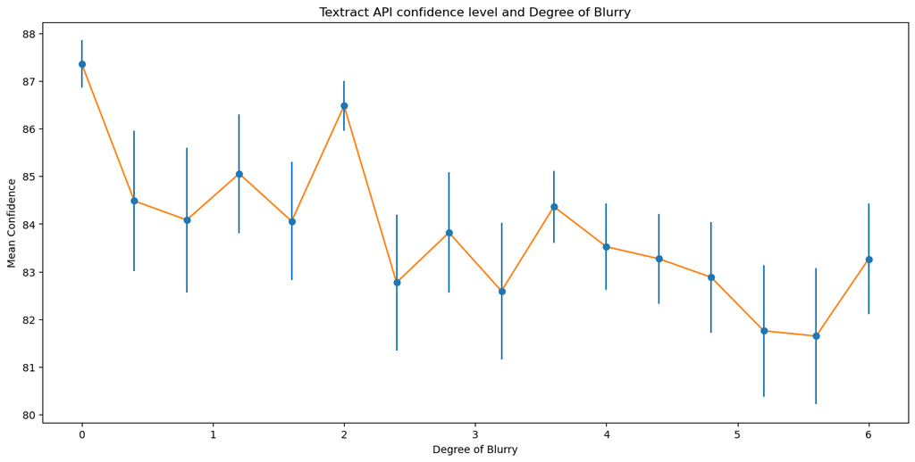

```python
import matplotlib.pyplot as plt
plt.figure(figsize=(15, 7))
x=np.asarray(blurry_df['blurry'])
y=np.asarray(blurry_df['Mean Confidence'])

# Plot the data with error bars
plt.errorbar(x, y, yerr=y_error, fmt='o')

# Add labels and title
plt.plot(x,y)
plt.xlabel('Degree of Blurry')
plt.ylabel('Mean Confidence')
plt.title('Textract API confidence level and Degree of Blurry')


# Show the plot
plt.show()
```

From the chart, we can see clearly the general trend that the more blurry the image is, the less confidence there is for the Textract outcome. Nevertheless, despite the clearest image has the highest mean confidence level (as expected), the blurries image is not the lowest ranked observation by outcome confidence level, as observations with blurriness around 5 to 5.5 give even less confidence than the observation wuth blurry level 6.

### Extract the table from Nonblurry image

Next, we want to compare the extracted content of the text by cell and see the mismatch rate between the original image and the blurry ones.

To begin with, we prepare the extracted table for the scanned image using Textract, and we do so for both the original image and the blurred image respectively.

*** Below are the steps to apply Textract on an image and extract a dataframe as the output, and one can use the below few blocks as a walk-through for using this AWS service:**

- Get image path:

```python
image_folder = 'blurry-images/'
image_path=image_folder+'blur0.0_im.JPG'
im = Image.open(image_path)
buffered = io.BytesIO()
im.save(buffered, format='PNG')
```

- Create an instance client of the client object in the boto3 package for Textract. It will allow use to communicate and make requests to the Textract service using Python:

```python
client = boto3.client('textract')
response = client.analyze_document(
    Document={'Bytes': buffered.getvalue()},
    FeatureTypes=['TABLES']
)
```

- Define functions in Python that allows us to extract and print the tables from Textract output:

```python
# functions for extracting and printing tables in Python
def map_blocks(blocks, block_type):
    return {
        block['Id']: block
        for block in blocks
        if block['BlockType'] == block_type
    }

blocks = response['Blocks']
tables = map_blocks(blocks, 'TABLE')
cells = map_blocks(blocks, 'CELL')
words = map_blocks(blocks, 'WORD')
selections = map_blocks(blocks, 'SELECTION_ELEMENT')
```

```python
def get_children_ids(block):
    for rels in block.get('Relationships', []):
        if rels['Type'] == 'CHILD':
            yield from rels['Ids']
```

- Run a loop structure to extract each cell in the table:

```python
import pandas as pd

dataframes = []

for table in tables.values():

    # Determine all the cells that belong to this table
    table_cells = [cells[cell_id] for cell_id in get_children_ids(table)]

    # Determine the table's number of rows and columns
    n_rows = max(cell['RowIndex'] for cell in table_cells)
    n_cols = max(cell['ColumnIndex'] for cell in table_cells)
    content = [[None for _ in range(n_cols)] for _ in range(n_rows)]

    # Fill in each cell
    for cell in table_cells:
        cell_contents = [
            words[child_id]['Text']
            if child_id in words
            else selections[child_id]['SelectionStatus']
            for child_id in get_children_ids(cell)
        ]
        i = cell['RowIndex'] - 1
        j = cell['ColumnIndex'] - 1
        content[i][j] = ' '.join(cell_contents)

    # We assume that the first row corresponds to the column names
    dataframe = pd.DataFrame(content[1:], columns=content[0])
    dataframes.append(dataframe)
```

- Print the output dataframe for the unblurred, original picture:

```python
df_unblur=dataframes[0]
df_unblur
```

|  | Airline | TFP | Scale Effect | Output Effect | Eff. Effect | Technical Change | Price Effect | Load Factor | Stage Length |
| --- | --- | --- | --- | --- | --- | --- | --- | --- | --- |
| 0 | AA | 0.7195 | -0.0189 | 0.0686 | 0.0063 | 0.274 | -0.1270 | 0.3584 | 0.1578 |
| 1 | AL | 1.3782 | 0.2140 | -0.0626 | 0.1945 | 0.274 | -0.0976 | 0.4873 | 0.3682 |
| 2 | BR | 0.5067 | 0.0377 | 0.1717 | -0.0294 | 0.274 | -0.0814 | 0.0041 | 0.1297 |
| 3 | CO | 0.4529 | 0.0517 | 0.1058 | 0.0261 | 0.274 | -0.1101 | -0.0017 | 0.1066 |
| 4 | DL | 0.3665 | -0.0109 | 0.0011 | 0.0180 | 0.274 | -0.0632 | 0.0093 | 0.1378 |
| 5 | EA | 0.4613 | -0.0174 | 0.0085 | 0.0489 | 0.274 | -0.1216 | 0.2038 | 0.0648 |
| 6 | FL | 1.1749 | 0.2108 | -0.0817 | 0.0435 | 0.274 | -0.1497 | 0.4287 | 0.4490 |
| 7 | NC | 1.8818 | 0.4639 | -0.0385 | 0.1132 | 0.274 | 0.0098 | 0.4256 | 0.6335 |
| 8 | OZ | 1.0371 | 0.2694 | -0.0417 | 0.0717 | 0.274 | -0.1033 | 0.0492 | 0.5175 |
| 9 | PI | 1.4081 | 0.3548 | 0.0116 | -0.0256 | 0.274 | -0.0225 | 0.3069 | 0.5086 |
| 10 | UA | 0.5864 | -0.0284 | 0.0430 | -0.0576 | 0.274 | -0.1400 | 0.3020 | 0.1931 |
| 11 | WA | 0.6202 | 0.0483 | -0.0237 | -0.0317 | 0.274 | -0.1120 | 0.3249 | 0.1342 |
| 12 | Avg. | 0.8723 | 0.1317 | 0.0148 | 0.0308 | 0.274 | -0.0937 | 0.2303 | 0.2835 |

This is the table output for the original image.

### Extract tables from the blurred images

After creating the blurry images directory, we repeat the extraction process for the blurred images as well.

```python
image_folder = 'blurry-images/'
for files in os.listdir(image_folder):
    if files == ".ipynb_checkpoints":
        continue
    image_path=image_folder+f'{files}'

    print(image_path)
```

```
blurry-images/blur3.6_im.JPG
blurry-images/blur2.8000000000000003_im.JPG
blurry-images/blur4.800000000000001_im.JPG
blurry-images/blur1.2000000000000002_im.JPG
blurry-images/blur3.2_im.JPG
blurry-images/blur5.2_im.JPG
blurry-images/blur1.6_im.JPG
blurry-images/blur2.4000000000000004_im.JPG
blurry-images/blur2.0_im.JPG
blurry-images/blur6.0_im.JPG
blurry-images/blur0.4_im.JPG
blurry-images/blur4.0_im.JPG
blurry-images/blur5.6000000000000005_im.JPG
blurry-images/blur0.0_im.JPG
blurry-images/blur4.4_im.JPG
blurry-images/blur0.8_im.JPG
```

```python
scanned_blur=[]
image_folder = 'blurry-images/'
for files in os.listdir(image_folder):
    if files == ".ipynb_checkpoints":
        continue
    image_path=image_folder+f'{files}'
    im = Image.open(image_path)
    buffered = io.BytesIO()
    im.save(buffered, format='PNG')
    client = boto3.client('textract')
    response = client.analyze_document(Document={'Bytes': buffered.getvalue()},FeatureTypes=['TABLES'])

    def map_blocks(blocks, block_type):
        return {block['Id']: block for block in blocks if block['BlockType'] == block_type}
    blocks = response['Blocks']
    tables = map_blocks(blocks, 'TABLE')
    cells = map_blocks(blocks, 'CELL')
    words = map_blocks(blocks, 'WORD')
    selections = map_blocks(blocks, 'SELECTION_ELEMENT')

    def get_children_ids(block):
        for rels in block.get('Relationships', []):
            if rels['Type'] == 'CHILD':
                yield from rels['Ids']

    dataframes=[]

    for table in tables.values():

        # Determine all the cells that belong to this table
        table_cells = [cells[cell_id] for cell_id in get_children_ids(table)]

        # Determine the table's number of rows and columns
        n_rows = max(cell['RowIndex'] for cell in table_cells)
        n_cols = max(cell['ColumnIndex'] for cell in table_cells)
        content = [[None for _ in range(n_cols)] for _ in range(n_rows)]

        # Fill in each cell
        for cell in table_cells:
            cell_contents = [
                words[child_id]['Text']
                if child_id in words
                else selections[child_id]['SelectionStatus']
                for child_id in get_children_ids(cell)
            ]
            i = cell['RowIndex'] - 1
            j = cell['ColumnIndex'] - 1
            content[i][j] = ' '.join(cell_contents)

        # We assume that the first row corresponds to the column names
        dataframe = pd.DataFrame(content[1:], columns=content[0])
        dataframes.append(dataframe)
    scanned_blur.append(dataframes)
```

Finally, we compile all extracted dataframes into a list.

```python
# sixtenn input images, therefore sixteen responses from texttract
len(scanned_blur)
```

```
16
```

### Compare the results from the blurry image and the original image

```python
# how the extracted data frame looks like
scanned_blur[0]
```

```
[   Airline     TFP Scale Effect Output Effect Eff. Effect Technical Change  \
 0       AA  0.7195      -0.0189        0.0686      0.0063            0.274
 1       AL  1.3782       0.2140       -0.0626      0.1945            0.274
 2       BR  0.5067       0.0377        0.1717     -0.0294            0.274
 3       CO  0.4529       0.0517        0.1058      0.0261            0.274
 4       DL  0.3665      -0.0109        0.0011      0.0180            0.274
 5       EA  0.4613      -0.0174        0.0085      0.0489            0.274
 6       FL  1.1749       0.2108       -0.0817      0.0435            0.274
 7       NC  1.8818       0.4639       -0.0385      0.1132            0.274
 8       oz  1.0371       0.2694       -0.0417      0.0717            0.274
 9       PI  1.4081       0.3548        0.0116     -0.0256            0.274
 10      UA  0.5864      -0.0284        0.0430     -0.0576            0.274
 11      WA  0.6202       0.0483       -0.0237     -0.0317            0.274
 12    Avg.  0.8723       0.1317        0.0148      0.0308            0.274

    Price Effect Load Factor Stage Length
 0       -0.1270      0.3584       0.1578
 1       -0.0976      0.4873       0.3682
 2       -0.0814      0.0041       0.1297
 3       -0.1101     -0.0017       0.1066
 4       -0.0632      0.0093       0.1378
 5       -0.1216      0.2038       0.0648
 6       -0.1497      0.4287       0.4490
 7        0.0098      0.4256       0.6335
 8       -0.1033      0.0492       0.5175
 9       -0.0225      0.3069       0.5086
 10      -0.1400      0.3020       0.1931
 11      -0.1120      0.3249       0.1342
 12      -0.0937      0.2303       0.2835  ]
```

Here, we calculate the mismatched rate for each of the blurred images. This is a procedure to compare the content cell by cell, i.e., if the cell of the table from the blurred image contains different content than the same cell of the table from the original image, then we mark it as one instance of mismatch.

Intuitively, we expect the mismatch to be more frequent in images with higher blurriness.

```python
cell_comparison=pd.DataFrame()
mismatched=[]
percent_mis=[]
for i in range(len(degree)):
    # Compare the two DataFrames element-wise
    not_equal_mask = scanned_blur[i][0].ne(df_unblur)
    total=not_equal_mask.shape[0]*not_equal_mask.shape[1]
    # Count the number of cells that are not equal
    num_not_equal_cells = not_equal_mask.sum().sum()
    mismatched.append(num_not_equal_cells)
    percent_mis.append(num_not_equal_cells/total)

cell_comparison['mismatched cell']=sorted(mismatched)
cell_comparison['blurry']=degree
cell_comparison['percent mismatched']=sorted(percent_mis)
cell_comparison
```

|  | mismatched cell | blurry | percent mismatched |
| --- | --- | --- | --- |
| 0 | 0 | 0.0 | 0.000000 |
| 1 | 0 | 0.4 | 0.000000 |
| 2 | 0 | 0.8 | 0.000000 |
| 3 | 0 | 1.2 | 0.000000 |
| 4 | 0 | 1.6 | 0.000000 |
| 5 | 0 | 2.0 | 0.000000 |
| 6 | 0 | 2.4 | 0.000000 |
| 7 | 0 | 2.8 | 0.000000 |
| 8 | 1 | 3.2 | 0.008547 |
| 9 | 1 | 3.6 | 0.008547 |
| 10 | 1 | 4.0 | 0.008547 |
| 11 | 2 | 4.4 | 0.017094 |
| 12 | 38 | 4.8 | 0.292308 |
| 13 | 77 | 5.2 | 0.538462 |
| 14 | 130 | 5.6 | 0.769231 |
| 15 | 174 | 6.0 | 0.892308 |

We further visualize the relationship in a line chart below:

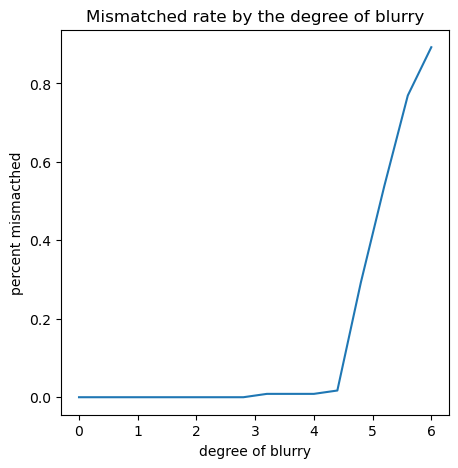

```python
plt.figure(figsize=(5,5))
plt.plot(cell_comparison['blurry'],cell_comparison['percent mismatched'])
plt.xlabel('degree of blurry')
plt.ylabel('percent mismacthed')
plt.title('Mismatched rate by the degree of blurry')
plt.show()
```

To give the audience a sense of the blurriness variation, we also include the actual samples after the blurriness treatment.

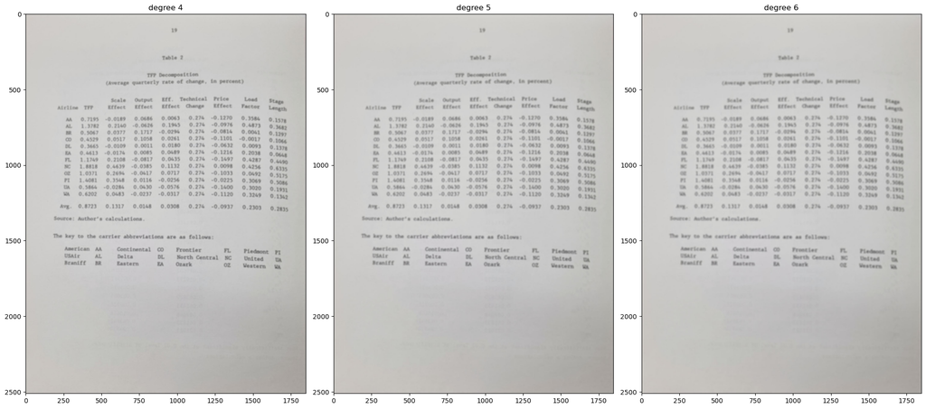

```python
import matplotlib.image as mpimg

plt.figure(figsize=(20,20))

image_path1 = './blurry-images/blur4.0_im.JPG'
image_path2 = './blurry-images/blur5.2_im.JPG'
image_path3 = './blurry-images/blur6.0_im.JPG'

# Load images using mpimg.imread
img1 = mpimg.imread(image_path1)
img2 = mpimg.imread(image_path2)
img3 = mpimg.imread(image_path3)

plt.subplot(1, 3, 1)
plt.imshow(img1)
plt.title('degree 4')

plt.subplot(1, 3, 2)
plt.imshow(img2)
plt.title('degree 5')

plt.subplot(1, 3, 3)
plt.imshow(img3)
plt.title('degree 6')

# Adjust layout to prevent overlapping titles
plt.tight_layout()

# Show the subplots
plt.show()
```

We can see that for degree 5 and 6, the image becomes so unclear that it is very hard to identify the text by eye. Therefore, it is reasonable that Textract performs less well in that case.

Admittedly, in daily usage and research work, we would not expect the input image resolution to be this poorly, and we can see that if the image is blurry from degree 0 to 3, the mismatch percentage is very close to zero. Therefore, we still feel comfortable about the validity of Textract and its normal use cases.

# Double-column page with complex format and more data points

To take our analysis a step further, we wonder if Textract can uphold the accuracy level as the input data structure becomes more complex.

To test this question, we deliberately chose the below image. This picture contains return data for stock indexes worldwide, as well as a handful of individual stocks' performance data. We will replicate the same procedure with this sample to see if there is any identifiable difference in the outcome.

```python
image_path = "localdir/newspaper/double_col.jpg"

# Save the uploaded image as JPEG
from PIL import Image
im = Image.open(image_path)
#im.save('uploaded_image.jpg')
import io
buffered = io.BytesIO()
im.save(buffered, format='PNG')
```

[figure not shown]

Like previously, we blur the image from 0 to 6 degree.

```python
from PIL import Image, ImageFilter
folder_path = 'col-images'

if os.path.exists(folder_path):
    # If it exists, remove the folder and its contents
    shutil.rmtree(folder_path)

os.makedirs(folder_path, exist_ok=True)

degree=np.linspace(0,6,16)

for i in degree:
    blur_im=im.filter(ImageFilter.BoxBlur(i))
    imname='col'+f'{i}'+'_im.JPG'
    image_path = os.path.join(folder_path, imname)
    blur_im.save(image_path)
```

Then, we calculate the confidence interval and funnel the findings to a dataframe.

```python
import os
import boto3
import numpy as np
from scipy import stats
import pandas as pd
import warnings
warnings.filterwarnings('ignore')


# Create a Textract client
client = boto3.client('textract')

# Specify the folder containing images
image_folder = 'col-images'

# DataFrame to store results
results_df = pd.DataFrame(columns=['Image', 'Mean Confidence', 'Confidence Interval'])

# Iterate through each image in the folder
for filename in os.listdir(image_folder):
    if filename.endswith(".jpg") or filename.endswith(".JPG"):  # Adjust file extensions as needed
        image_path = os.path.join(image_folder, filename)

        # Read the image as bytes
        with open(image_path, 'rb') as image_file:
            image_bytes = image_file.read()

        # Call Textract's analyze_document API
        response = client.analyze_document(Document={'Bytes': image_bytes}, FeatureTypes=['TABLES'])

        # Process the response and extract confidence values
        confidence_values = [block['Confidence'] for block in response['Blocks'] if block['BlockType'] == 'CELL']

        # Calculate confidence interval
        confidence_interval = stats.t.interval(0.95, len(confidence_values)-1, loc=np.mean(confidence_values), scale=stats.sem(confidence_values))

        # Save results to DataFrame
        results_df = results_df.append({
            'Image': filename,
            'Mean Confidence': np.mean(confidence_values),
            'Confidence Interval': confidence_interval
        }, ignore_index=True)

# Print or save the DataFrame as needed
print(results_df)
# results_df.to_csv('confidence_results.csv', index=False)  # Uncomment to save to a CSV file
```

```
                           Image  Mean Confidence  \
0   col5.6000000000000005_im.JPG        75.953391
1                  col0.0_im.JPG        82.768209
2                  col0.8_im.JPG        81.381685
3                  col4.4_im.JPG        73.266656
4                  col0.4_im.JPG        82.085912
5                  col4.0_im.JPG        73.373116
6                  col2.0_im.JPG        79.544364
7   col2.4000000000000004_im.JPG        77.726759
8                  col6.0_im.JPG        77.204233
9                  col3.6_im.JPG        72.304569
10                 col3.2_im.JPG        73.830502
11  col1.2000000000000002_im.JPG        81.081046
12   col4.800000000000001_im.JPG        76.068709
13  col2.8000000000000003_im.JPG        75.458304
```

[output cut: 20 more lines]

```python
blurry_df=pd.DataFrame()
for i in degree:
    imname='col'+f'{i}'+'_im.JPG'
    blurry_df=blurry_df.append(results_df[results_df['Image']==imname])

blurry_df=blurry_df.reset_index().drop('index', axis=1)
```

```python
blurry_df['blurry']=degree
blurry_df
```

|  | Image | Mean Confidence | Confidence Interval | blurry |
| --- | --- | --- | --- | --- |
| 0 | col0.0_im.JPG | 82.768209 | (82.03991687895403, 83.49650112436454) | 0.0 |
| 1 | col0.4_im.JPG | 82.085912 | (81.33175427804939, 82.8400688690745) | 0.4 |
| 2 | col0.8_im.JPG | 81.381685 | (80.63568083893998, 82.1276885609494) | 0.8 |
| 3 | col1.2000000000000002_im.JPG | 81.081046 | (80.2948978976928, 81.86719419301517) | 1.2 |
| 4 | col1.6_im.JPG | 79.407332 | (78.5577115013217, 80.25695335625574) | 1.6 |
| 5 | col2.0_im.JPG | 79.544364 | (78.68914990312842, 80.3995790100353) | 2.0 |
| 6 | col2.4000000000000004_im.JPG | 77.726759 | (76.77943242264139, 78.67408579500243) | 2.4 |
| 7 | col2.8000000000000003_im.JPG | 75.458304 | (74.43925310001303, 76.47735451198919) | 2.8 |
| 8 | col3.2_im.JPG | 73.830502 | (72.69806921127602, 74.96293396903371) | 3.2 |
| 9 | col3.6_im.JPG | 72.304569 | (71.18562770153767, 73.42350963944685) | 3.6 |
| 10 | col4.0_im.JPG | 73.373116 | (72.29141135356686, 74.45482067076942) | 4.0 |
| 11 | col4.4_im.JPG | 73.266656 | (72.15981170253806, 74.37349944928715) | 4.4 |
| 12 | col4.800000000000001_im.JPG | 76.068709 | (75.11425102264651, 77.02316774118093) | 4.8 |
| 13 | col5.2_im.JPG | 77.034361 | (76.00288987685761, 78.06583246827515) | 5.2 |
| 14 | col5.6000000000000005_im.JPG | 75.953391 | (74.94531061521924, 76.96147087676086) | 5.6 |
| 15 | col6.0_im.JPG | 77.204233 | (76.03205744156993, 78.37640926888362) | 6.0 |

Like previously, we also make a plot to see how confidence changes with the degree of blurry:

```python
y_error=[]
for i in range(blurry_df.shape[0]):
    y_error.append(blurry_df['Confidence Interval'][i][1]-blurry_df['Mean Confidence'][i])

y_error=np.asarray(y_error)
```

[figure not shown]

```python
import matplotlib.pyplot as plt
plt.figure(figsize=(15, 7))
x=np.asarray(blurry_df['blurry'])
y=np.asarray(blurry_df['Mean Confidence'])

# Plot the data with error bars
plt.errorbar(x, y, yerr=y_error, fmt='o')

# Add labels and title
plt.plot(x,y)
plt.xlabel('Degree of Blurriness')
plt.ylabel('Mean Confidence')
plt.title('Textract API confidence level and Degree of Blurriness')


# Show the plot
plt.show()
```

Next, we extracted the tables from the original image and each of the blurred images, and we complie all the tables into a list.

### Extraction example from the nonblurry image

```python
image_folder = 'col-images/'
image_path=image_folder+'col0.0_im.JPG'
im = Image.open(image_path)
buffered = io.BytesIO()
im.save(buffered, format='PNG')
```

```python
client = boto3.client('textract')
response = client.analyze_document(
    Document={'Bytes': buffered.getvalue()},
    FeatureTypes=['TABLES']
)
```

```python
# functions for extracting and printing tables in Python
def map_blocks(blocks, block_type):
    return {
        block['Id']: block
        for block in blocks
        if block['BlockType'] == block_type
    }

blocks = response['Blocks']
tables = map_blocks(blocks, 'TABLE')
cells = map_blocks(blocks, 'CELL')
words = map_blocks(blocks, 'WORD')
selections = map_blocks(blocks, 'SELECTION_ELEMENT')
```

```python
def get_children_ids(block):
    for rels in block.get('Relationships', []):
        if rels['Type'] == 'CHILD':
            yield from rels['Ids']
```

```python
import pandas as pd

dataframes = []

for table in tables.values():

    # Determine all the cells that belong to this table
    table_cells = [cells[cell_id] for cell_id in get_children_ids(table)]

    # Determine the table's number of rows and columns
    n_rows = max(cell['RowIndex'] for cell in table_cells)
    n_cols = max(cell['ColumnIndex'] for cell in table_cells)
    content = [[None for _ in range(n_cols)] for _ in range(n_rows)]

    # Fill in each cell
    for cell in table_cells:
        cell_contents = [
            words[child_id]['Text']
            if child_id in words
            else selections[child_id]['SelectionStatus']
            for child_id in get_children_ids(cell)
        ]
        i = cell['RowIndex'] - 1
        j = cell['ColumnIndex'] - 1
        content[i][j] = ' '.join(cell_contents)

    # We assume that the first row corresponds to the column names
    dataframe = pd.DataFrame(content[1:], columns=content[0])
    dataframes.append(dataframe)
```

```python
df_unblur=dataframes[0]
df_unblur
```

|  | Region/Country | Index | Close | Net chg | Latest % chg | YTD % chg |
| --- | --- | --- | --- | --- | --- | --- |
| 0 | World | MSCIACWI | 664.42 | -1.03 | -0.16 | 9,8 |
| 1 |  | MSCIACWIex-USA | 288.74 | -2.90 | -0.99 | 2,6 |
| 2 |  | MSCI World | 2887.39 | -2.05 | -0.07 | 10.9 |
| 3 |  | MSCI Emerging Markets | 960.66 | -8.25 | -0.85 | 0,4 |
| 4 | Americas | MSCI AC Americas | 1657.28 | 4.66 | 0.28 | 13,7 |
| 5 | Canada | S&P/TSX Comp | 19575.59 | -168.35 | -0.85 | 1.0 |
| 6 | Latin Amer. | MSCIEM Latin America | 2361.87 | 10.83 | 0.46 | 11.0 |
| 7 | Brazil | BOVESPA | 119268.06 | 836.81 | 0.71 | 8.7 |
| 8 | Chile | S&P IPSA | 3180.07 | 42.37 | 1.35 | 0.2 |
| 9 | Mexico | S&P/BMV IPC | 51209.85 | -423.78 | -0.82 | 5.7 |
| 10 | EMEA | STOXX Europe 600 | 442.81 | -0.71 | -0.16 | 4.2 |
| 11 | Eurozone | Euro STOXX | 436.01 | -0.65 | -0.15 | 6.4 |
| 12 | Belgium | Bel-20 | 3462.94 | -11.07 | -0.32 | -6.4 |
| 13 | Denmark | OMX Copenhagen 20 | 2188.43 | 4.06 | 0.19 | 19.2 |
| 14 | France | CAC 40 | 6986.23 | -27.50 | -0.39 | 7.9 |
| 15 | Germany | DAX | 15152.64 | 16.67 | 0.11 | 8.8 |
| 16 | Israel | Tel Aviv | 1728.11 | 25.55 | 1.50 | -3.8 |
| 17 | Italy | FTSE MIB | 28395.90 | -196.70 | -0.69 | 19.8 |
| 18 | Netherlands | AEX | 735.74 | 0.40 | 0.05 | 6.8 |
| 19 | Norway | Osio Bors All-Share | 1485.36 | -33.19 | -2.19 | 9.0 |
| 20 | South Africa | FTSE/JSE All-Share | 71572.99 | -1720.70 | -2.35 | -2.0 |
| 21 | Spain | IBEX 35 | 9235.88 | -5.60 | -0.06 | 12.2 |
| 22 | Sweden | OMX Stockholm | 786.63 | -1.92 | -0.24 | 0.6 |
| 23 | Switzerland | Swiss Market | 10571.03 | -5.72 | -0.05 | -1.5 |
| 24 | Turkey | BIST 100 | 7844.80 | -23.22 | -0.30 | 42.4 |
| 25 | U.K. | FTSE 100 | 7410.04 | -7.72 | -0.10 | -0.6 |
| 26 | U.K. | FTSE 250 | 17761.71 | 14.24 | 0.08 | -5.8 |
| 27 | Asia-Pacific | MSCI AC Asia Pacific | 157.61 | -2.12 | -1.33 | 1.2 |
| 28 | Australia | S&P/ASX 200 | 6977.10 | -20.28 | -0.29 | -0.9 |
| 29 | China | Shanghai Composite | 3057.27 | -1.14 | -0.04 | -1.0 |
| 30 | Hong Kong | Hang Seng | 17670.16 | -296.43 | -1.65 | -10.7 |
| 31 | India | S&P BSE Sensex | 64942.40 | -16.30 | -0.03\| | 6.7 |
| 32 | Japan | NIKKEI 225 | 32271.82 | -436.66 | -1.34 | 23.7 |
| 33 | Singapore | Straits Times | 3173.81 | -6.73 | -0.21 | -2.4 |
| 34 | South Korea | KOSPI | 2443.96 | -58.41 | -2.33 | 9.3 |
| 35 | Taiwan | TAIEX | 16684.95 | 35.59 | 0.21 | 18.0 |
| 36 | Thailand | SET | 1408.30 | -8.91 | -0.63 | -15.6 |

This is the content for the unblurred, original image.

### Extraction from the blurry images

```python
image_folder = 'col-images/'
for files in os.listdir(image_folder):
    if files == ".ipynb_checkpoints":
        continue
    image_path=image_folder+f'{files}'

    print(image_path)
```

```
col-images/col5.6000000000000005_im.JPG
col-images/col0.0_im.JPG
col-images/col0.8_im.JPG
col-images/col4.4_im.JPG
col-images/col0.4_im.JPG
col-images/col4.0_im.JPG
col-images/col2.0_im.JPG
col-images/col2.4000000000000004_im.JPG
col-images/col6.0_im.JPG
col-images/col3.6_im.JPG
col-images/col3.2_im.JPG
col-images/col1.2000000000000002_im.JPG
col-images/col4.800000000000001_im.JPG
col-images/col2.8000000000000003_im.JPG
col-images/col5.2_im.JPG
col-images/col1.6_im.JPG
```

```python
scanned_blur=[]
image_folder = 'col-images/'
for files in os.listdir(image_folder):
    if files == ".ipynb_checkpoints":
        continue
    image_path=image_folder+f'{files}'
    im = Image.open(image_path)
    buffered = io.BytesIO()
    im.save(buffered, format='PNG')
    client = boto3.client('textract')
    response = client.analyze_document(Document={'Bytes': buffered.getvalue()},FeatureTypes=['TABLES'])

    def map_blocks(blocks, block_type):
        return {block['Id']: block for block in blocks if block['BlockType'] == block_type}
    blocks = response['Blocks']
    tables = map_blocks(blocks, 'TABLE')
    cells = map_blocks(blocks, 'CELL')
    words = map_blocks(blocks, 'WORD')
    selections = map_blocks(blocks, 'SELECTION_ELEMENT')

    def get_children_ids(block):
        for rels in block.get('Relationships', []):
            if rels['Type'] == 'CHILD':
                yield from rels['Ids']

    dataframes=[]

    for table in tables.values():

        # Determine all the cells that belong to this table
        table_cells = [cells[cell_id] for cell_id in get_children_ids(table)]

        # Determine the table's number of rows and columns
        n_rows = max(cell['RowIndex'] for cell in table_cells)
        n_cols = max(cell['ColumnIndex'] for cell in table_cells)
        content = [[None for _ in range(n_cols)] for _ in range(n_rows)]

        # Fill in each cell
        for cell in table_cells:
            cell_contents = [
                words[child_id]['Text']
                if child_id in words
                else selections[child_id]['SelectionStatus']
                for child_id in get_children_ids(cell)
            ]
            i = cell['RowIndex'] - 1
            j = cell['ColumnIndex'] - 1
            content[i][j] = ' '.join(cell_contents)

        # We assume that the first row corresponds to the column names
        dataframe = pd.DataFrame(content[1:], columns=content[0])
        dataframes.append(dataframe)
    scanned_blur.append(dataframes)
```

```python
# sixtenn input images, therefore sixteen responses from texttract
len(scanned_blur)
```

```
16
```

```python
# how the extracted data frame looks like
scanned_blur[0]
```

```
[                                   -     Class        -    the with time
 0            I              was ACME                -14      -        14
 1                                MSO    288.74    -2.00    AME        24
 2                          MSO World   2802.29      -20    447        as
 3                       was Energing         -      425    481        04
 4      America        MSO AC America               4.44               az
 5      Canalia            SANTA Comp      2017        -    481        14
 6                                         INLO      and              110
 7        Bruel               DOVESPA                 DM    147        87
 8          One                                       es    BL#        02
 9      Mission             summer IN    summer      427    401        17
 10        EMEA                 STORY       see      471    -42        42
 11      Europe            Item STOCK       our       de    425        64
 12      Suigum                     -      MAIN    -0.07   -432        44
 13      Common    CHECK Caparhagan =       nae     4.06     42       282
```

[output cut: 51 more lines]

Like previously, we still use the extracted table from the unblurred original image as the benchmark and see how much each of the table frm the blurred images misses the content cell by cell.

```python
cell_comparison=pd.DataFrame()
mismatched=[]
percent_mis=[]
for i in range(len(degree)):
    # Compare the two DataFrames element-wise
    not_equal_mask = scanned_blur[i][0].ne(df_unblur)
    total=not_equal_mask.shape[0]*not_equal_mask.shape[1]
    # Count the number of cells that are not equal
    num_not_equal_cells = not_equal_mask.sum().sum()
    mismatched.append(num_not_equal_cells)
    percent_mis.append(num_not_equal_cells/total)

cell_comparison['mismatched cell']=sorted(mismatched)
cell_comparison['blurry']=degree
cell_comparison['percent mismatched']=sorted(percent_mis)
cell_comparison
```

|  | mismatched cell | blurry | percent mismatched |
| --- | --- | --- | --- |
| 0 | 0 | 0.0 | 0.000000 |
| 1 | 7 | 0.4 | 0.031532 |
| 2 | 7 | 0.8 | 0.031532 |
| 3 | 12 | 1.2 | 0.054054 |
| 4 | 14 | 1.6 | 0.063063 |
| 5 | 15 | 2.0 | 0.067568 |
| 6 | 88 | 2.4 | 0.339768 |
| 7 | 226 | 2.8 | 0.678679 |
| 8 | 300 | 3.2 | 0.810811 |
| 9 | 374 | 3.6 | 0.918919 |
| 10 | 378 | 4.0 | 0.928747 |
| 11 | 444 | 4.4 | 1.000000 |
| 12 | 444 | 4.8 | 1.000000 |
| 13 | 444 | 5.2 | 1.000000 |
| 14 | 444 | 5.6 | 1.000000 |
| 15 | 444 | 6.0 | 1.000000 |

We can also spot this significant inaccuracy surge in the plot below:

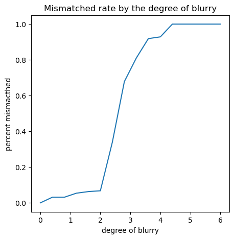

```python
plt.figure(figsize=(5,5))
plt.plot(cell_comparison['blurry'],cell_comparison['percent mismatched'])
plt.xlabel('degree of blurry')
plt.ylabel('percent mismacthed')
plt.title('Mismatched rate by the degree of blurry')
plt.show()
```

The outcome starts to become unreliable starting blurry degree = 2, and it becomes inaccurate very quickly.

[figure not shown]

```python
import matplotlib.image as mpimg

plt.figure(figsize=(20,20))

image_path1 = './col-images/col2.0_im.JPG'
image_path2 = './col-images/col4.0_im.JPG'
image_path3 = './col-images/col6.0_im.JPG'

# Load images using mpimg.imread
img1 = mpimg.imread(image_path1)
img2 = mpimg.imread(image_path2)
img3 = mpimg.imread(image_path3)

plt.subplot(1, 3, 1)
plt.imshow(img1)
plt.title('degree 2')

plt.subplot(1, 3, 2)
plt.imshow(img2)
plt.title('degree 4')

plt.subplot(1, 3, 3)
plt.imshow(img3)
plt.title('degree 6')

# Adjust layout to prevent overlapping titles
plt.tight_layout()

# Show the subplots
plt.show()
```

We can also see this with our eyes - when the image is level 2 blurred, we can still try to identify the content, but it becomes indecipherable when the blurry degree reaches 4, which is where the Textract outcome also becomes very inaccurate.

To conclude, we find that the accuracy level of Textract decreases as the input image layout gets more complicated. For more complex data sources, the input image needs to have higher resolution for the Textract output to be meaningful. When working with simpler data sources, there is a larger tolerance on the image quality for Textract to operate, but when the user is working with more compact and complicated data layout, they need to ensure decent image resolution to extract the content accurately.